# hw7

```python
import numpy as np
import matplotlib.pyplot as plt
```

**Exercise 6.1.1**

For each IVP, determine whether the problem satisfies the conditions of Theom 6.1.2. If so, determine the smallest possible value for $L$.

(a) $f(t,u)=3u$, $0\leq t\leq1$

$$\frac{\partial f}{\partial u}=3\\ |3|\leq 3=L$$

(b) $f(t,u)=-t\sin(u)$, $0\leq t\leq5$

$$\frac{\partial f}{\partial u}=-t\cos(u)\\ |-t\cos(u)|=t\cos(u)\leq 5\cos(0)=5=L$$

(c) $f(t,u)=-(1+t^2)u^2$, $1\leq t\leq3$

$$\frac{\partial f}{\partial u}=-2(1+t^2)u$$

This function is not bounded by a constant $L$ since the $u$ term can scale $|-2(1+t^2)|$ arbitrarily large.

(d) $f(t,u)=\sqrt{u}$, $0\leq t\leq1$

$$\frac{\partial f}{\partial u}=\frac{1}{2}u^{-1/2}$$

This function is not bounded by a constant $L$ since $u=0$ blows up to infinity.

**Exercise 6.1.4**

Consider the IVP $u'=u^2$, $u(0)=\alpha$.

(a) Does Theorem 6.1.1 apply to this problem?

Theorem 6.1.1 does not apply to this problem. $\partial f/\partial u=2u$, which isn't bounded by a constant $L$ since $u$ can be arbitrarily large.

(b) Show that $u(t)=\alpha / (1-\alpha t)$ is a solution of the IVP.

$$\begin{align*} u'(t)&=(\alpha(1-\alpha t)^{-1})'\\ &=-\alpha(1-\alpha t)^2\cdot(-\alpha)\\ &=\alpha^2(1-\alpha t)^{-2}\\ &=(\alpha/(1-\alpha t))^2\\ &=u^2 \end{align*}$$

**Exercise 6.2.1**

Do two steps of Euler's method for the following problems using the given step size $h$. Then, compute the error using the given exact solution.

(a) $u'=-2tu,u(0)=2;h=0.1;\hat{u}(t)=2e^{-t^2}$

$$\begin{align*} u_1&=u_0+hf(t_0,u_0)=2+0.1(-2(0)(2))2\\ u_2&=u_1+hf(t_0+h,u_1)=2+0.1(-2(0.1)(2))=1.96 \end{align*}\\ \hat{u}(t_0+2h)=1.921578878\\ |1.921578878-1.96|=0.0384211217 $$

(b) $u'=u+t,u(0)=2;h=0.2;\hat{u}(t)=-1-t+3e^t$

$$\begin{align*} u_1&=u_0+hf(t_0,u_0)=2+0.2(2+0)=2.4\\ u_2&=u_1+hf(t_0+h,u_1)=2.4+0.2(2.4+0.2)=2.92 \end{align*}\\ \hat{u}(t_0+2h)=3.075474093\\ |3.075474093-2.92|=0.1554740929 $$

(c) $tu'+u=1,u(1)=6;h=0.25;\hat{u}(t)=1+5/t$

$$u'=(1-u)/t\\ \begin{align*} u_1&=u_0+hf(t_0,u_0)=6+0.25((1-6)/1)=4.75\\ u_2&=u_1+hf(t_0+h,u_1)=4.75+0.25((1-4.75)/0.25)=1\\ \end{align*}\\ \hat{u}(t_0+2h)=11\\ |11-1|=10 $$

(d) $u'-2u(1-u)=0,u(0)=1/2;h=0.25;\hat{u}(t)=1/(1+e^{-2t})$

$$u'=2u(1-u)\\ \begin{align*} u_1&=u_0+hf(t_0,u_0)=0.5+0.25(2(0.5)(1-0.5))=0.625\\ u_2&=u_1+hf(t_0+h,u_1)=0.625+0.25(2(0.625)(1-0.625))=0.7421875\\ \end{align*}\\ \hat{u}(t_0+2h)=0.7310585786\\ |0.7310585786-0.7421875|=0.0111289214 $$

**Exercise 6.3.1**

Rewrite the given higher order problems as first-order systems.

(a) $y'''-3y''+3y'-y=t,y(0)=1,y'(0)=2,y''(0)=3$

Where $u_i=y^{(i-1)},$

$$\begin{align*} u'_1&=u_2\\ u'_2&=u_3\\ u'_3&=t+u_1-3u_2+3u_3\\ \end{align*}\\ u_1(0)=1,u_2(0)=2,u_3(0)=3$$

(b) $y''+4(x^2-1)y'+y=0,y(0)=2,y'(0)=-1$

Where $u_i=y^{(i-1)}$,

$$\begin{align*} u'_1&=u_2\\ u'_2&=-u_1-4(x^2-1)u_2 \end{align*}\\ u_1(0)=2,u_2(0)=-1$$

**Exercise 6.3.2**

Write the given IVP as a system. Then do two steps of Euler's method by hand (perhaps with a calculator) with the indicated step size $h$. Using the given exact solution, compute the error after the second step.

(a) $y''+4y=4t,y(0)=1,y'(0)=1;\hat{y}(t)=t+\cos(2t),h=0.1$

Where $u_i=y^{(i-1)}$,

$$\begin{align*} u'_1&=u_2\\ u'_2&=4t-4u_1 \end{align*}\\ u_1(0)=1,u_2(0)=1$$

$$\begin{align*} \begin{bmatrix}u_1\\ u_2\end{bmatrix}_1&=\begin{bmatrix}u_1\\ u_2\end{bmatrix}_0+h\begin{bmatrix}f_1(t_0,u_{1,0})\\ f_2(t_0,u_{2,0})\end{bmatrix}=\begin{bmatrix}1\\1\end{bmatrix}+0.1\begin{bmatrix}1\\ 4(0)-4(1)\end{bmatrix}=\begin{bmatrix}1.1\\0.6\end{bmatrix}\\ \begin{bmatrix}u_1\\ u_2\end{bmatrix}_2&=\begin{bmatrix}u_1 \\ u_2\end{bmatrix}_1+h\begin{bmatrix}f_1(t_0+h,u_{1,1})\\ f_2(t_0+h,u_{2,1})\end{bmatrix}=\begin{bmatrix}1.1\\0.6\end{bmatrix}+0.1\begin{bmatrix}1.1\\ 4(0.1)-4(1.1)\end{bmatrix}=\begin{bmatrix}1.21\\0.2\end{bmatrix} \end{align*}\\ \hat{y}(t_0+2h)=1.121060994\\ |1.121060994-1.21|=0.088939006$$

**Exercise 6.4.1**

For each IVP, write out (possibly using a calculator) the first time step of the improved Euler method with $h=0.2$.

(a) $u'=-2tu,0\leq t\leq2,u(0)=2;\hat{u}(t)=2e^{-t^2}$

$$\begin{align*} u_1&=u_0+hf(t_0+(1/2)h,u_0+(1/2)hf(t_0,u_0))\\ &=2+0.2f(0+(1/2)(0.2),2+(1/2)(0.2)(-2(0)(2))))\\ &=2+0.2f(0.1,2)\\ &=2+0.2(-2(0.1)(2))\\ &=1.92 \end{align*}$$

**Exercise 6.5.1**

Using Function 6.5.2 with an error tolerance of $10^{-8}$, solve $y''+(1+y')^3y=0$ over $0\leq t\leq4\pi$ with the indicated initial conditions. Plot $y(t)$ and $y'(t)$ as functions of $t$ and separately plot the time step size as a function of $t$.

```python
def rk23(du_dt, tspan, u0, tol):
    """
    rk23(du_dt, tspan, u0, tol)

    Apply adaptive embedded RK formula to solve the vector-valued IVP u'=du_dt(u,p,t)
    over the interval tspan with u(tspan[1])=u0, with error tolerance tol.
    Return a vector of times and a vector of solution values/vectors.
    """
    # Initialize for the first time step.
    t = [tspan[0]]
    u = np.array([np.atleast_1d(u0)])
    i = 0
    h = 0.5 * tol ** (1 / 3)
    s1 = du_dt(t[0], u[0])

    # Time stepping.
    while t[i] < tspan[-1]:
        # Detect underflow of the step size.
        if t[i] + h == t[i]:
            print(f"Stepsize too small near t={t[i]}")
            break  # quit time stepping loop

        # New RK stages.
        s2 = du_dt(t[i] + h / 2, u[i] + (h / 2) * s1)
        s3 = du_dt(t[i] + 3 * h / 4, u[i] + (3 * h / 4) * s2)
        unew2 = u[i] + h * (2 * s1 + 3 * s2 + 4 * s3) / 9  # 2rd order solution
        s4 = du_dt(t[i] + h, unew2)
        err = h * (-5 * s1 / 72 + s2 / 12 + s3 / 9 - s4 / 8)  # 2nd/3rd order difference
        E = np.linalg.norm(err, np.inf)  # error estimate
        maxerr = tol * (1 + np.linalg.norm(u[i], np.inf))  # relative/absolute blend

        # Accept the proposed step?
        if E < maxerr:  # yes
            t.append(t[i] + h)
            u = np.vstack([u, unew2])
            i += 1
            s1 = s4  # use FSAL property

        # Adjust step size.
        q = 0.8 * (maxerr / E) ** (1 / 3)  # conservative optimal step factor
        q = min(q, 4)  # limit stepsize growth
        h = min(q * h, tspan[-1] - t[i])  # don't step past the end

    # Convert outputs to arrays
    return np.array(t), u.T
```

(a) $y(0)=0.1,y'(0)=0$

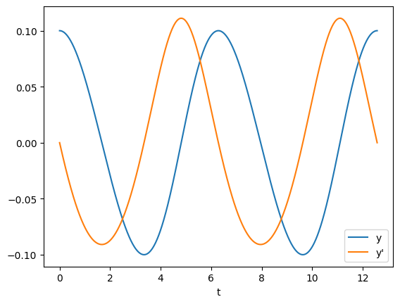

```python
f = lambda t, u: np.array([u[1], -(1+u[1]) ** 3 * u[0]])
t, u = rk23(f, [0, 4 * np.pi], [0.1, 0], 1e-8)

plt.plot(t, u[0, :], label = "y")
plt.plot(t, u[1, :], label = "y'")
plt.xlabel("t")
plt.legend()
plt.show()
```

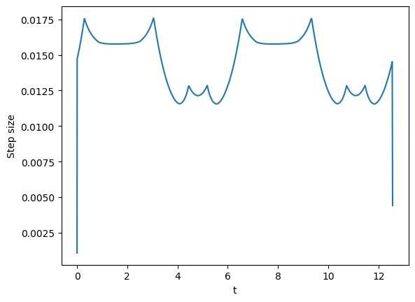

```python
dt = [t[i + 1] - t[i] for i in range(t.size - 1)]
plt.plot(t[:-1], dt)
plt.xlabel("t")
plt.ylabel("Step size")
plt.show()
```

**Exercise 6.6.1**

For each method, write out the generating polynomials $\rho(z)$ and $\sigma(z)$.

(a) AM2

$\rho(z)=z-1$, $\sigma(z)=\frac{1}{2}z+\frac{1}{2}$

(b) AB2

$\rho(z)=z^2-z$, $\sigma(z)=\frac{3}{2}z-\frac{1}{2}$

(c) BD2

$\rho(z)=z^2-\frac{4}{3}z+\frac{1}{3}$, $\sigma(z)=\frac{2}{3}z^2$

(d) AM3

$\rho(z)=z^2-z$, $\sigma(z)=\frac{5}{12}z^2+\frac{8}{12}z-\frac{1}{12}$

(e) AB3

$\rho(z)=z^3-z^2$, $\sigma(z)=\frac{23}{12}z^2-\frac{16}{12}z+\frac{5}{12}$

**Exercise 6.6.2**

Find the solution value $u_1$ produced by AM1 (backward Euler) for each IVP. (Reminder: This is an implicit formula, so you may need to solve a nonlinear equation. If there are multiple possible values for $u_1$, choose the one closest to $u_0$.)

(a) $u'=-2tu,0\leq t\leq2,u_0=3,h=0.2$

$$u_{i+1}=u_i+hf_{i+1}=u_i+hf(t_{i+1},u_{i+1})$$

So $$\begin{align*}u_1&=u_0+hf(t_1,u_1)\\ &=3+(0.2)(-2(0.2)(u_1))\\ &=3-0.08u_1\\ \to 1.08u_1&=3\\ \to u_1&=2.\bar{7} \end{align*}$$